# The Architecture of Intelligence

Past, Present & Future of AI

Ravi Kalia, PhD

2026-08-03

## Objective

- Survey definitions of AI, linking them with biology and academic tribes working on AI over past, present and future.

[figure not shown]

Seventy-five years of moving the goalposts — most of these names recur tonight

## Acknowledgements

- **Leonardo Donando**
- **Jonathan Florez Giraldo**
- **Alex Kuznetsov**
- **Delany Adom**
- **Andrei Alain González Galeano**
- **Pedro Domingos** — for *The Master Algorithm* and the five tribes

*With gratitude for their contributions.*

- **Intelligence is Task Solving** by learning
- **Minds run on prediction** — animal, human, machine alike
- **“AI” is an Ambiguous Term** — today, a marketing label for LLMs
- **Human intelligence is Sample Efficient Novel Task Solving** — written first in our biology
- Good prediction indicates learning

## Outline

- I Minds: consciousness & animals
- II Human intelligence as machine learning
- III “AI”: an ambiguous term
- *— coffee —*
- IV Generative AI & LLMs
- V The five tribes
- VI State of the art
- VII What we want from AGI
- VIII The future

## I. Minds: Consciousness & Animals

## Sentience vs. Sapience

- **Sentience** — to feel, to experience (qualia)
- **Sapience** — to judge, to act with wisdom
- Today’s AI mimics sapience, shows no sentience
- That asymmetry is the hard problem

## Self-Awareness

- Introspection — the self as distinct from the world
- A thinker and a sculpted head: a mind watching itself think
- Not the same as intelligence, nor consciousness
- Perhaps a prerequisite for both

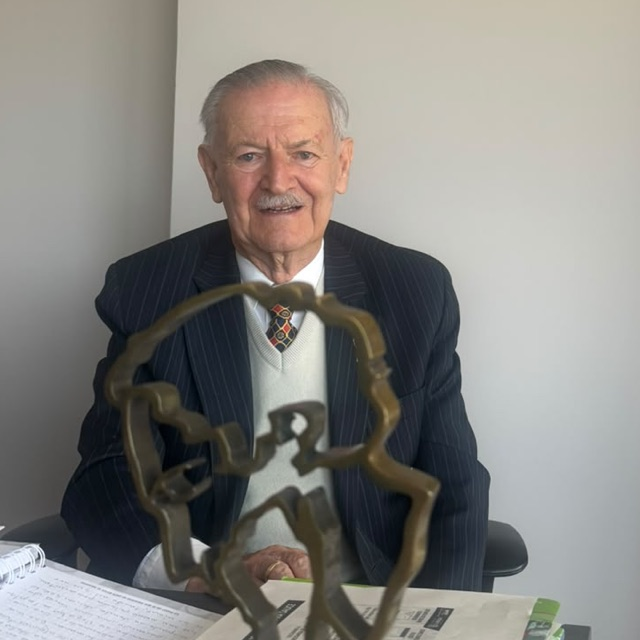

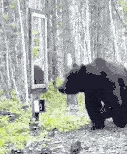

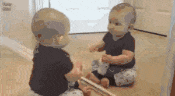

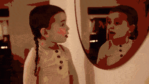

## A Ladder of Agency

1. Thermostat / bacterium — reactive feedback
2. Dog — bonding, mapping, goals
3. Octopus — distributed cognition, tool use
4. Dolphin — self-recognition, communication
5. Human — metacognition, culture

## Primate: Our Closest Relative

- Shared ancestry — chimps, bonobos ~6–7 Mya
- Primate cognition: a rough draft of ours
- The differences are as instructive as the likenesses

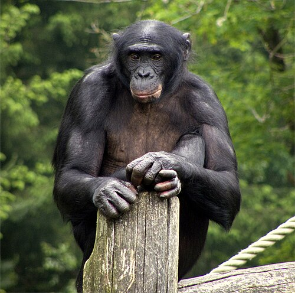

Bonobo

## Octopus: Intelligence Reinvented

- Last common ancestor ~550 Mya
- Evolved **completely independently** of ours
- A true natural experiment in cognition
- Similar solutions → convergence is real

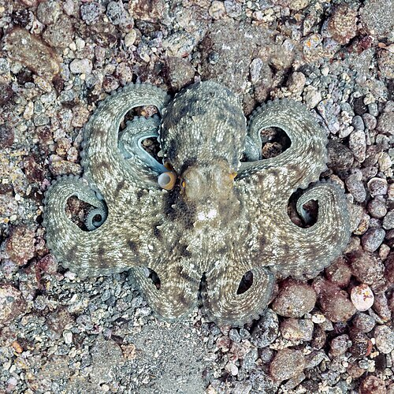

## Messi: Football Intelligence

- Growth-hormone deficiency as a child — physical limits may have driven *compensatory* perception
- Reads play patterns before they unfold — anticipation over speed
- Like chess intuition: pattern recognition, not raw calculation
- A human specialization of the same predictive engine
- *Caveat: the hormone–cognition link is a popular theory, not proven*

[figure not shown]

Getafe, 2007 — the pattern, read early

## Emotion → Feeling → Sentiment

- **Emotion** — raw input; a valence signal: good or bad, now?
- **Feeling** — the conscious experience of that input
- **Sentiment** — a compressed label from expressed feelings
- Machine analogues: reward signals, then sentiment analysis

[figure not shown]

## Friston: Prediction Under Uncertainty

- The brain predicts the world, not just records it
- Free Energy Principle: minimize surprise
- Consciousness as ongoing active inference

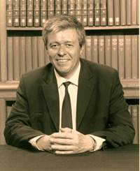

$$\underset{\color{#f0a868}{\textbf{posterior}}}{\color{#f0a868}{P(\text{world} \mid \text{sense})}} \;\;\propto\;\; \underset{\color{#63b3a6}{\textbf{likelihood}}}{\color{#63b3a6}{P(\text{sense} \mid \text{world})}} \;\;\cdot\;\; \underset{\color{#7aa0e0}{\textbf{prior}}}{\color{#7aa0e0}{P(\text{world})}}$$

## II. Human Intelligence as Machine Learning

## Why Intelligence Evolved

- **An unstable niche** — the world kept moving
- Two bets: **brittle instinct** or **costly inference**
- We paid to **learn within a lifetime**
- **Tools are the evidence** of that inference
- Three capacities: **world-modelling, transmission, practice**

[figure not shown]

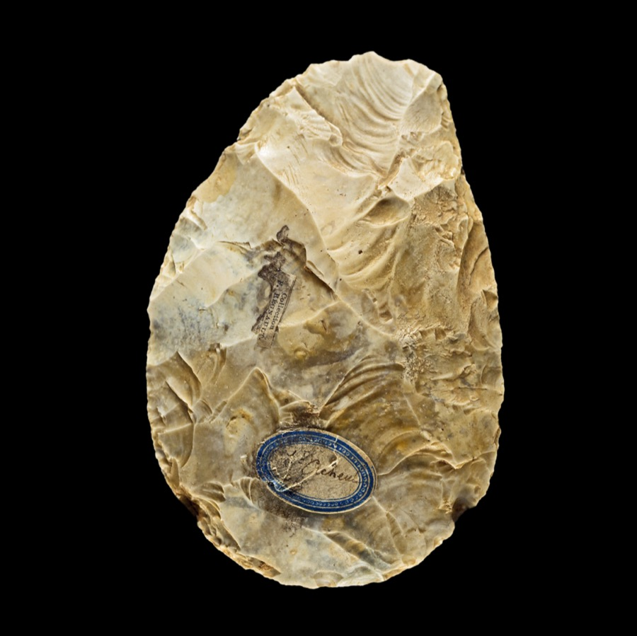

Out of Africa into everything — and the handaxe that went with us, barely changed for 300,000 years

## Human Intelligence Properties

- Short-Term and Long-Term Memory
- Sample Efficiency — learn from a few examples
- Generalization & Transfer
- Compositionality & Abstraction
- Causal Reasoning, Metacognition, Grounding

## Supervised Learning

- Map inputs → labeled outputs
- Told the answer; adjust to cut error
- Bottleneck: the cost of labels
- Human parallel: a student with an answer key

## Self-Supervised Learning

- Data supplies its own labels — predict the masked word
- The engine behind foundation models
- The internet becomes supervision, unannotated
- Human parallel: an infant learning by observation

## Unsupervised Learning

- No labels — find structure in the data itself
- Clustering, dimensionality reduction, density estimation
- Reveals hidden groupings and manifolds
- Human parallel: noticing categories no one named

[figure not shown]

## Reinforcement Learning

- Learn from reward and consequence
- Powers game-players and chat-model tuning
- The agent generates its own training signal
- Human parallel: a child learning by trial, reward, and consequence

## Unifying View

- Self-supervised prediction builds the world model
- Reinforcement fine-tunes on top
- The same recipe in human brain and in models

## III. “AI”: An Ambiguous Term

## Beginning: Dartmouth, 1956

- McCarthy chose “artificial intelligence”
- The conjecture: intelligence can be *“so precisely described that a machine can be made to simulate it”*
- They thought a summer and 10 assistants would do it.

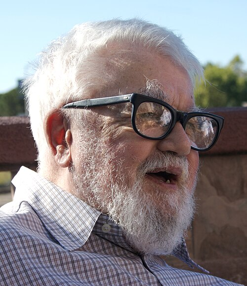

McCarthy

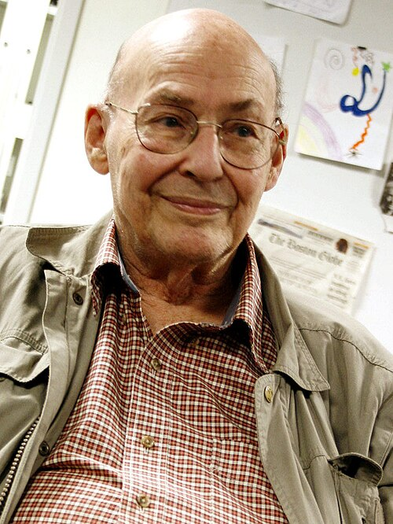

Minsky

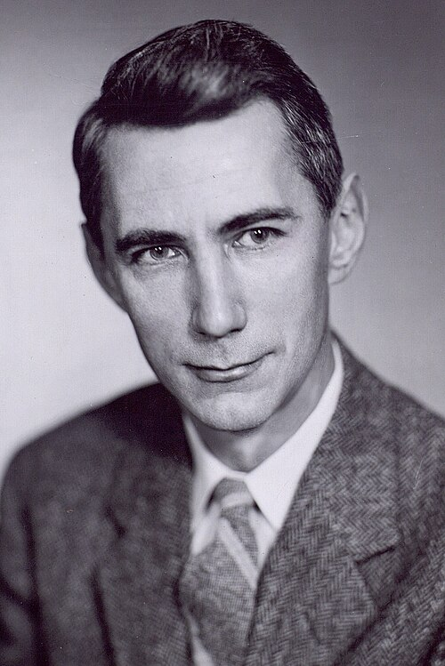

Shannon

with Nathaniel Rochester — the four  
who signed the 1955 proposal

## Four Acronyms

- **ML** — algorithms that improve at a task with more data
- **ANI** — narrow: superhuman at one task, useless outside it
- **AGI** — general: human-level breadth, *novel* tasks included
- **ASI** — beyond: exceeds the best humans at essentially everything

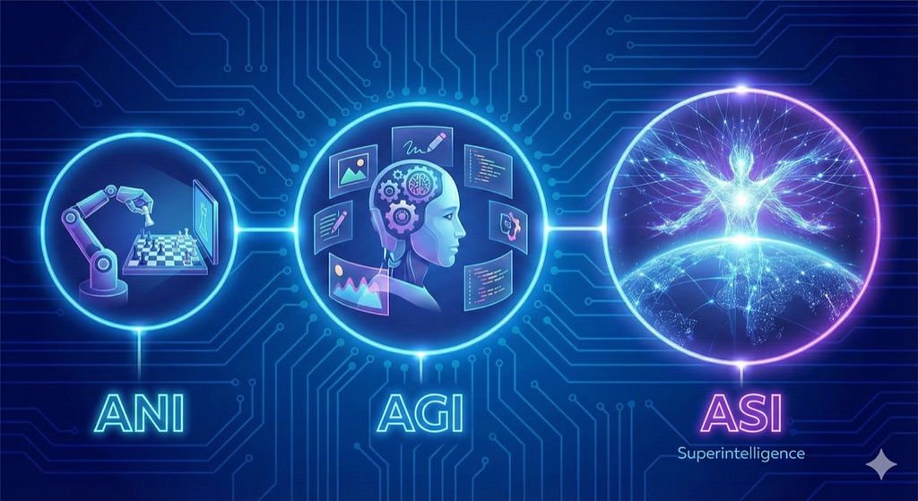

ANI is here · AGI is the aspiration · ASI is the artwork

## Make Coffee

- Functionalist test: a machine does what a human did — intelligent?
- Once we see the mechanism, we stop calling it AI
- Chess, OCR, translation — “AI” until it worked
- Make coffee in any kitchen in the world
- “AI” often means: *not yet understood*

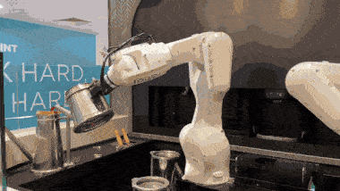

Coffee, yes — but in a rig built for it, not *any* kitchen

## Turing Test

- Imitation: indistinguishable in text → passes
- Says nothing about internal states
- Cited often, engineered against rarely
- A floor, not a ceiling

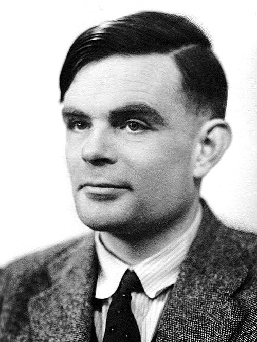

## Russell & Norvig: Agents

- Act to achieve the best expected outcome
- The textbook definition — agent, environment, measure
- Says nothing about *how* — only that it decides well

## Chollet: Intelligence as Adaptation

- Efficiency at acquiring *new* skills
- Adaptation, not static performance
- The machine echo of human skill acquisition
- Memorize well, adapt poorly → not intelligent

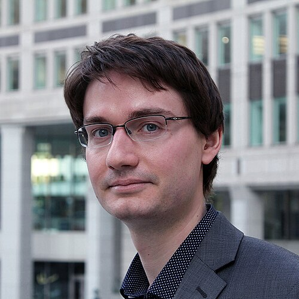

## One Definition of Knowledge

- **Data** — raw, uncompressed
- **Compression** — redundancy found
- **Abstraction** — the reusable structure it yields
- **Prediction** — the test on unseen data
- **Knowledge** — abstraction that keeps passing

Process **data** to generate **knowledge**

## Knowledge as Compression

Three traditional sources of knowledge:

- **Genes** — survival encoded by evolution
- **Experience** — direct interaction
- **Culture** — collective wisdom, transmitted

A fourth new source, over the last 50 years:

- **Computers** — synthesis at scale

## ☕ Coffee Break

*15 minutes — please join us in the foyer*

## IV. Generative AI & LLMs

## What Gen AI Is

- Simulation from a partially learned distribution; produces new samples
- Text, image, audio, code
- Self-supervised pre-training + the transformer
- Planetary scale recursive classification simulation

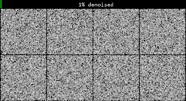

Noise → sample: a diffusion model inventing characters

## What Gen AI Is Not

- No guarantee of truth, cause, or grounding
- Fluency is not knowledge
- It compresses culture and lets us query it
- New and powerful — not a mind

## The LLM

- A next-token predictor over human text
- No persistent memory, weak causal models
- Unreliable deliberate reasoning
- A statistical reflection of us

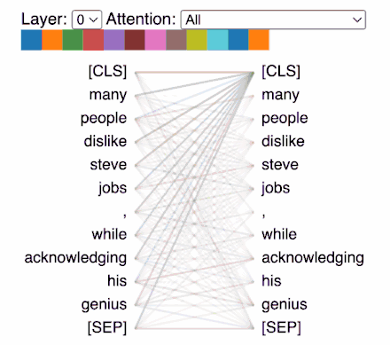

Attention, layer by layer — every token weighing every other

## V. The Five Tribes

## Symbolists — Logic and Deduction

- Roots: logic — Newell & Simon’s symbol system hypothesis
- Learning = inverse deduction; rules, trees, expert systems
- Precise and auditable — but brittle
- Optimization: combinatorial search over rule/hypothesis space
- Modern echo: neuro-symbolic AI, formal verification
- EXAMPLE: Routing Email Complaints

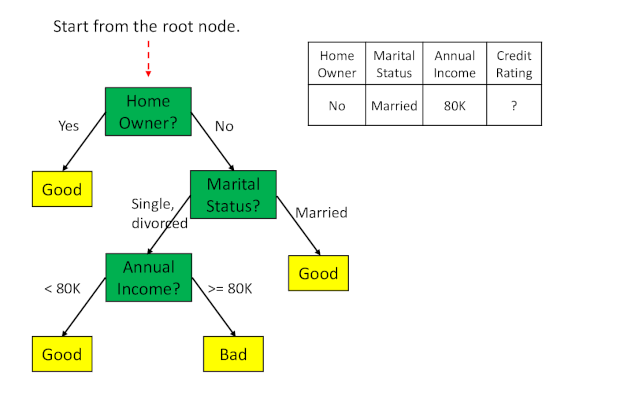

Every answer comes with its own audit trail

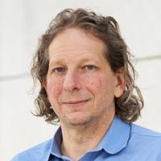

Josh Tenenbaum

## Connectionists — Brain Inspired

- Roots: McCulloch–Pitts (1943), Rosenblatt’s perceptron (1958)
- Backpropagation (1986) → CNNs → transformers
- Optimization: stochastic gradient descent via backpropagation
- Scales with data and compute — and dominates today
- EXAMPLE: Making DNA viral capsids

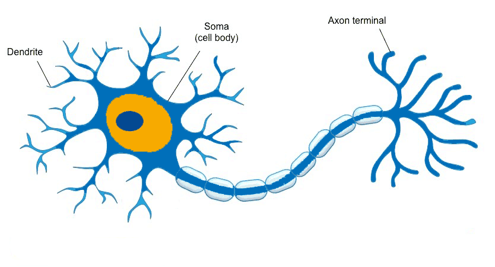

Dendrites in, axon out — the unit they copied

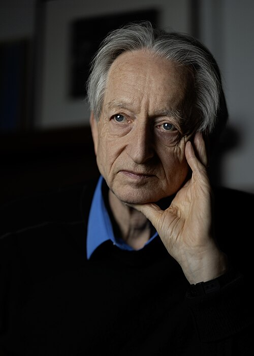

Hinton

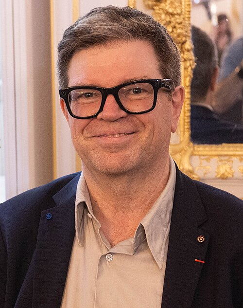

LeCun

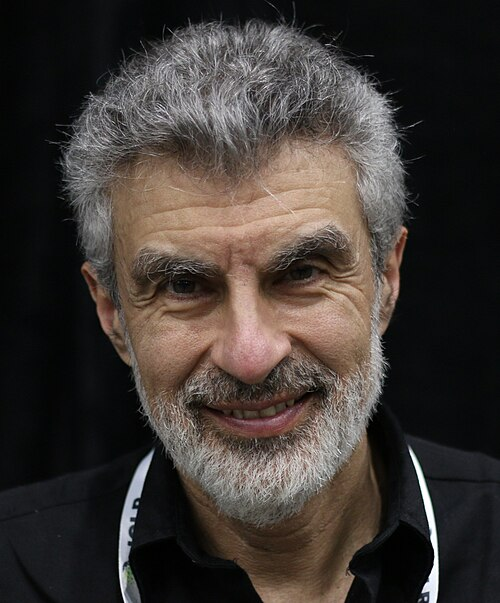

Bengio

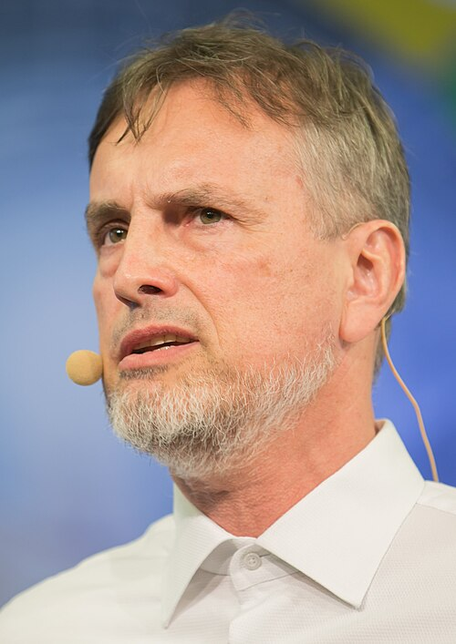

Schmidhuber